# Crashes Data Analysis

2023-07-18

The setup

```r
library(pROC)
library(car)
nyc.collisions.weather.tod.final <- read.csv("~/Desktop/nyc-collisions-weather-tod-final.csv")
df <- nyc.collisions.weather.tod.final

# Define IOD as 1 if there is an injury or a death

df$IOD <- ifelse(df$INJURY == 1 | df$DEATH == 1, 1, 0)
```

Background:

From the original three datasets, the following characteristics were selected for:

Complete data for all variables Only look at collisions involving two vehicles (vehicle 1 is denoted as _1, and vehicle 2 is denoted as _2) Only consider vehicles where the only occupant is the driver (that way we avoid the confounding effect that vehicles with multiple passengers are more likely to have injuries) Look at collisions involving vehicles belonging to a major class (e.g. no horse-drawn carriages)

The Variables:

Driver Sex

```r
#Drop records without driver sex
df <- df[df$DRIVER_SEX_1 %in% c("M", "F"),]
df <- df[df$DRIVER_SEX_2 %in% c("M", "F"),]

model_sex <- glm(IOD ~ DRIVER_SEX_1 + DRIVER_SEX_2 + DRIVER_SEX_1:DRIVER_SEX_2,family=binomial(link='logit'),data=df)

summary(model_sex)
```

```
##
## Call:
## glm(formula = IOD ~ DRIVER_SEX_1 + DRIVER_SEX_2 + DRIVER_SEX_1:DRIVER_SEX_2,
##     family = binomial(link = "logit"), data = df)
##
## Coefficients:
##                             Estimate Std. Error  z value Pr(>|z|)
## (Intercept)                 -1.35983    0.01307 -104.065  < 2e-16 ***
## DRIVER_SEX_1M               -0.05117    0.01567   -3.265  0.00109 **
## DRIVER_SEX_2M               -0.04931    0.01561   -3.159  0.00158 **
## DRIVER_SEX_1M:DRIVER_SEX_2M -0.10690    0.01861   -5.743 9.28e-09 ***
## ---
## Signif. codes:  0 '***' 0.001 '**' 0.01 '*' 0.05 '.' 0.1 ' ' 1
##
## (Dispersion parameter for binomial family taken to be 1)
##
##     Null deviance: 437438  on 458207  degrees of freedom
## Residual deviance: 436954  on 458204  degrees of freedom
## AIC: 436962
##
## Number of Fisher Scoring iterations: 4
```

```r
df$IOD.Pred <- predict(model_sex,newdata=df,type='response')

roc.test <- roc(df$IOD, df$IOD.Pred )
```

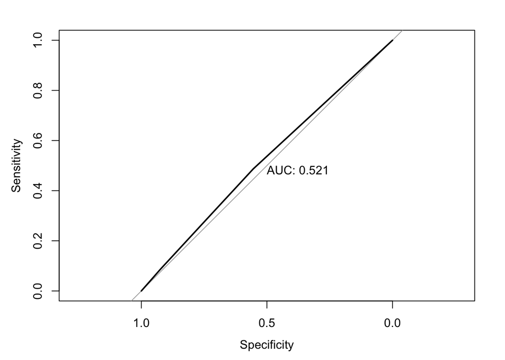

```r
plot(roc.test, print.auc = TRUE)
```

Sex is predictive at a high degree of confidence. Males have a lower risk of IOD than females, and the effect is the same for both drivers in the crash. It should be mentioned that this does not imply that women are worse or more dangerous drivers, just that they are more likely to suffer IOD in the event of a collision. (Or, rather, that an IOD is more likely to occur in a collision involving a woman driver or two women drivers).

Driver Age

```r
#Kicking out records with ages outside of a reasonable range

df <- df[df$DRIVER_AGE_1 >= 11,]
df <- df[df$DRIVER_AGE_1 <= 110,]
df <- df[df$DRIVER_AGE_2 <= 110,]
df <- df[df$DRIVER_AGE_2 >= 11,]

model_age <- glm(IOD ~ poly(DRIVER_AGE_1,2) + poly(DRIVER_AGE_2,2) + DRIVER_AGE_1:DRIVER_AGE_2,family=binomial(link='logit'),data=df)

summary(model_age)
```

```
##
## Call:
## glm(formula = IOD ~ poly(DRIVER_AGE_1, 2) + poly(DRIVER_AGE_2,
##     2) + DRIVER_AGE_1:DRIVER_AGE_2, family = binomial(link = "logit"),
##     data = df)
##
## Coefficients:
##                             Estimate Std. Error z value Pr(>|z|)
## (Intercept)               -1.382e+00  3.058e-02 -45.181  < 2e-16 ***
## poly(DRIVER_AGE_1, 2)1    -4.346e+01  7.525e+00  -5.776 7.64e-09 ***
## poly(DRIVER_AGE_1, 2)2     3.245e+01  2.586e+00  12.548  < 2e-16 ***
## poly(DRIVER_AGE_2, 2)1    -4.570e+01  7.562e+00  -6.044 1.50e-09 ***
## poly(DRIVER_AGE_2, 2)2     3.501e+01  2.582e+00  13.558  < 2e-16 ***
## DRIVER_AGE_1:DRIVER_AGE_2 -6.600e-05  1.715e-05  -3.848 0.000119 ***
## ---
## Signif. codes:  0 '***' 0.001 '**' 0.01 '*' 0.05 '.' 0.1 ' ' 1
##
## (Dispersion parameter for binomial family taken to be 1)
##
##     Null deviance: 434252  on 454863  degrees of freedom
## Residual deviance: 432289  on 454858  degrees of freedom
## AIC: 432301
##
## Number of Fisher Scoring iterations: 4
```

```r
df$IOD.Pred <- predict(model_age,newdata=df,type='response')

roc.test <- roc(df$IOD, df$IOD.Pred )
```

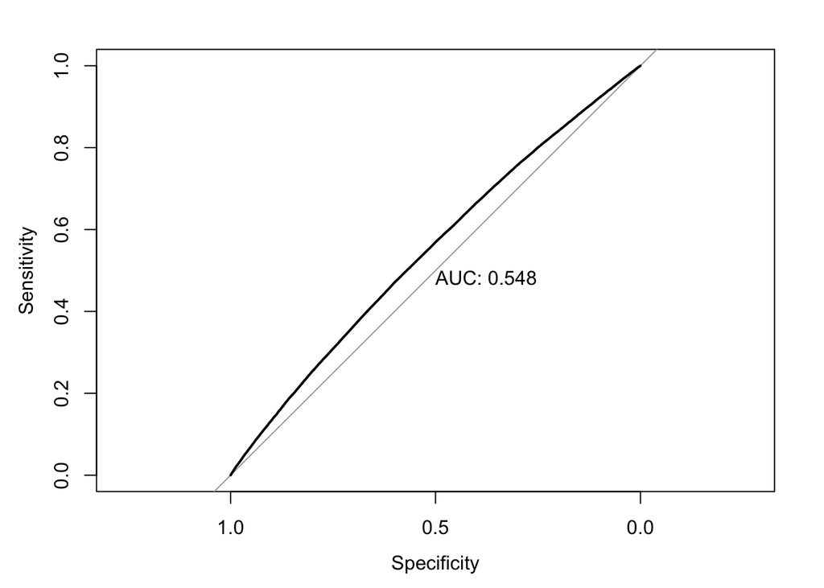

```r
plot(roc.test, print.auc = TRUE)
```

Licensing

```r
#1 if licensed, 0 otherwise

df$licensed_1 <- 0
df$licensed_2 <- 0
df$licensed_1[(df$DRIVER_LICENSE_STATUS_1 == 'Licensed')] <- 1
df$licensed_2[(df$DRIVER_LICENSE_STATUS_2 == 'Licensed')] <- 1


model_lic <- glm(IOD ~ licensed_1 + licensed_2 + licensed_1:licensed_2,family=binomial(link='logit'),data=df)

summary(model_lic)
```

```
##
## Call:
## glm(formula = IOD ~ licensed_1 + licensed_2 + licensed_1:licensed_2,
##     family = binomial(link = "logit"), data = df)
##
## Coefficients:
##                       Estimate Std. Error z value Pr(>|z|)
## (Intercept)            -0.3228     0.1433  -2.253 0.024262 *
## licensed_1             -0.5178     0.1459  -3.548 0.000388 ***
## licensed_2             -0.3989     0.1461  -2.731 0.006315 **
## licensed_1:licensed_2  -0.2741     0.1487  -1.842 0.065407 .
## ---
## Signif. codes:  0 '***' 0.001 '**' 0.01 '*' 0.05 '.' 0.1 ' ' 1
##
## (Dispersion parameter for binomial family taken to be 1)
##
##     Null deviance: 434252  on 454863  degrees of freedom
## Residual deviance: 433006  on 454860  degrees of freedom
## AIC: 433014
##
## Number of Fisher Scoring iterations: 4
```

```r
df$IOD.Pred <- predict(model_lic,newdata=df,type='response')

roc.test <- roc(df$IOD, df$IOD.Pred )
```

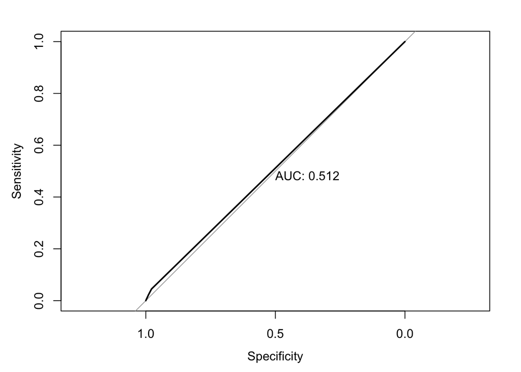

```r
plot(roc.test, print.auc = TRUE)
```

In-state Licensing

```r
df$instate_lic_1 <- 0
df$instate_lic_2 <- 0
df$instate_lic_2[(df$DRIVER_LICENSE_JURISDICTION_2 == 'NY')] <- 1
df$instate_lic_1[(df$DRIVER_LICENSE_JURISDICTION_1 == 'NY')] <- 1

model_instate <- glm(IOD ~ instate_lic_1 + instate_lic_2 + instate_lic_1:instate_lic_2,family=binomial(link='logit'),data=df)

summary(model_instate)
```

```
##
## Call:
## glm(formula = IOD ~ instate_lic_1 + instate_lic_2 + instate_lic_1:instate_lic_2,
##     family = binomial(link = "logit"), data = df)
##
## Coefficients:
##                             Estimate Std. Error z value Pr(>|z|)
## (Intercept)                 -2.01827    0.02947 -68.475  < 2e-16 ***
## instate_lic_1                0.37024    0.03183  11.633  < 2e-16 ***
## instate_lic_2                0.37734    0.03189  11.832  < 2e-16 ***
## instate_lic_1:instate_lic_2 -0.16242    0.03435  -4.728 2.27e-06 ***
## ---
## Signif. codes:  0 '***' 0.001 '**' 0.01 '*' 0.05 '.' 0.1 ' ' 1
##
## (Dispersion parameter for binomial family taken to be 1)
##
##     Null deviance: 434252  on 454863  degrees of freedom
## Residual deviance: 433376  on 454860  degrees of freedom
## AIC: 433384
##
## Number of Fisher Scoring iterations: 4
```

```r
df$IOD.Pred <- predict(model_instate,newdata=df,type='response')

roc.test <- roc(df$IOD, df$IOD.Pred )
```

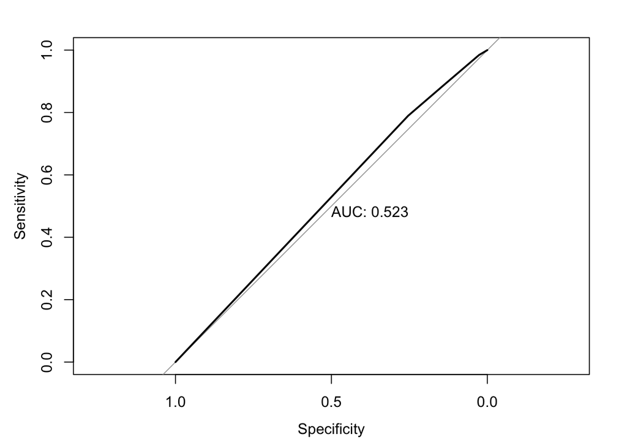

```r
plot(roc.test, print.auc = TRUE)
```

Very odd finding that in-state drivers are actually slightly *more* likely to be injured in an accident than out-of-state drivers. One possible explanation is that people in NYC don’t actually drive that much. The interaction term is also strange, indicating that the risk of IOD is lowered when there is a collision between two in-state drivers. No idea what’s going on here - let’s keep this in mind for the variable consolidation step.

Cleaning Up Car Make

```r
df$VM_1 <- substring(tolower(df$VEHICLE_MAKE_1),1,4)
df$VM_2 <- substring(tolower(df$VEHICLE_MAKE_2),1,4)

df$VM_1[grepl("kia",df$VM_1) == TRUE] <- "kia"
df$VM_1[grepl("bmw",df$VM_1) == TRUE] <- "bmw"
df$VM_1[grepl("isu",df$VM_1) == TRUE] <- "isuz"

df$VM_2[grepl("kia",df$VM_2) == TRUE] <- "kia"
df$VM_2[grepl("bmw",df$VM_2) == TRUE] <- "bmw"
df$VM_2[grepl("isu",df$VM_2) == TRUE] <- "isuz"

car_make_keeps <- c( 'toyt',  'hond',  'niss',  'ford',  'chev',  'hyun',  'merz',  'jeep',   'bmw',  'dodg',  'lexs',  'acur',  'infi',  'volk',  'suba',  'chry',   'kia',  'gmc',   'linc',  'audi',  'mazd')

df$VM_1[!(df$VM_1 %in% car_make_keeps)] <- 'allo'
df$VM_2[!(df$VM_2 %in% car_make_keeps)] <- 'allo'

#model_car_make1 <- glm(IOD ~ VM_1,family=binomial(link='logit'),data=df)
#model_car_make2 <- glm(IOD ~ VM_2,family=binomial(link='logit'),data=df)

#summary(model_car_make1)
#summary(model_car_make2)

#df$IOD.Pred <- predict(model_car_make,newdata=df,type='response')

#roc.test <- roc(df$IOD, df$IOD.Pred )

#plot(roc.test, print.auc = TRUE)
```

Car Safety

```r
model_car_make1 <- glm(IOD ~ VM_1,family=binomial(link='logit'),data=df)
model_car_make2 <- glm(IOD ~ VM_2,family=binomial(link='logit'),data=df)

summary(model_car_make1)
```

```
##
## Call:
## glm(formula = IOD ~ VM_1, family = binomial(link = "logit"),
##     data = df)
##
## Coefficients:
##              Estimate Std. Error z value Pr(>|z|)
## (Intercept) -1.443970   0.026219 -55.074  < 2e-16 ***
## VM_1allo    -0.194170   0.028129  -6.903 5.10e-12 ***
## VM_1audi    -0.153024   0.046014  -3.326 0.000882 ***
## VM_1bmw      0.053285   0.033705   1.581 0.113893
## VM_1chev    -0.129995   0.031821  -4.085 4.40e-05 ***
## VM_1chry     0.070127   0.041698   1.682 0.092609 .
## VM_1dodg    -0.008234   0.035222  -0.234 0.815148
## VM_1ford    -0.075742   0.029403  -2.576 0.009994 **
## VM_1hond     0.046554   0.028311   1.644 0.100100
## VM_1hyun     0.049670   0.032649   1.521 0.128173
## VM_1infi     0.118520   0.037380   3.171 0.001521 **
## VM_1jeep    -0.042265   0.033878  -1.248 0.212194
## VM_1kia      0.107947   0.042462   2.542 0.011016 *
## VM_1lexs    -0.176893   0.036560  -4.838 1.31e-06 ***
## VM_1linc    -0.017742   0.044287  -0.401 0.688695
## VM_1merz    -0.091789   0.033949  -2.704 0.006856 **
## VM_1niss     0.090132   0.028552   3.157 0.001595 **
## VM_1suba    -0.225945   0.043936  -5.143 2.71e-07 ***
## VM_1toyt    -0.076549   0.027673  -2.766 0.005671 **
## VM_1volk    -0.056410   0.041911  -1.346 0.178321
## ---
## Signif. codes:  0 '***' 0.001 '**' 0.01 '*' 0.05 '.' 0.1 ' ' 1
##
## (Dispersion parameter for binomial family taken to be 1)
##
##     Null deviance: 434252  on 454863  degrees of freedom
## Residual deviance: 433591  on 454844  degrees of freedom
## AIC: 433631
##
## Number of Fisher Scoring iterations: 4
```

```r
summary(model_car_make2)
```

```
##
## Call:
## glm(formula = IOD ~ VM_2, family = binomial(link = "logit"),
##     data = df)
##
## Coefficients:
##             Estimate Std. Error z value Pr(>|z|)
## (Intercept) -1.44314    0.02637 -54.731  < 2e-16 ***
## VM_2allo    -0.19803    0.02824  -7.013 2.34e-12 ***
## VM_2audi    -0.14742    0.04604  -3.202 0.001365 **
## VM_2bmw      0.07427    0.03393   2.189 0.028615 *
## VM_2chev    -0.09843    0.03178  -3.097 0.001954 **
## VM_2chry     0.03284    0.04190   0.784 0.433211
## VM_2dodg     0.05503    0.03506   1.570 0.116509
## VM_2ford    -0.10498    0.02954  -3.554 0.000379 ***
## VM_2hond     0.05081    0.02847   1.785 0.074298 .
## VM_2hyun     0.07206    0.03274   2.201 0.027744 *
## VM_2infi     0.12814    0.03756   3.412 0.000646 ***
## VM_2jeep    -0.02953    0.03411  -0.866 0.386570
## VM_2kia      0.05780    0.04345   1.330 0.183466
## VM_2lexs    -0.14934    0.03701  -4.035 5.46e-05 ***
## VM_2linc    -0.01961    0.04407  -0.445 0.656328
## VM_2merz    -0.08927    0.03420  -2.610 0.009047 **
## VM_2niss     0.08696    0.02872   3.028 0.002460 **
## VM_2suba    -0.18850    0.04389  -4.295 1.75e-05 ***
## VM_2toyt    -0.09091    0.02781  -3.269 0.001079 **
## VM_2volk    -0.03828    0.04140  -0.925 0.355185
## ---
## Signif. codes:  0 '***' 0.001 '**' 0.01 '*' 0.05 '.' 0.1 ' ' 1
##
## (Dispersion parameter for binomial family taken to be 1)
##
##     Null deviance: 434252  on 454863  degrees of freedom
## Residual deviance: 433560  on 454844  degrees of freedom
## AIC: 433600
##
## Number of Fisher Scoring iterations: 4
```

```r
#df$IOD.Pred <- predict(model_car_make,newdata=df,type='response')

#roc.test <- roc(df$IOD, df$IOD.Pred )

#plot(roc.test, print.auc = TRUE)
```

I do wonder to what extent brand safety is a proxy for car size or driver responsibility, but we do include the type of car (sedan vs SUV) and the vehicle weight, and the brand is still a statistically-significant variable. Whether the brand is statistically significant compared to driver responsibility is hard to answer - most drivers get to choose the car that their driving. An exception to this case is taxi drivers, who (typically) have to drive whatever car the taxi company is willing to lease them. Unfortunately, it isn’t clear if we have enough data to perform this analysis. Maybe another time …

```r
safe_cars_final <- c("toyt", "volv", "ford", "audi", "lexs", "suba", "merz", "chev")

df$safe_1 <- 0
df$safe_2 <- 0
df$safe_1[(df$VM_1 %in% safe_cars_final)] <- 1
df$safe_2[(df$VM_2 %in% safe_cars_final)] <- 1


model_car_safe <- glm(IOD ~ safe_1 + safe_2 + safe_1:safe_2,family=binomial(link='logit'),data=df)

summary(model_car_safe)
```

```
##
## Call:
## glm(formula = IOD ~ safe_1 + safe_2 + safe_1:safe_2, family = binomial(link = "logit"),
##     data = df)
##
## Coefficients:
##                Estimate Std. Error  z value Pr(>|z|)
## (Intercept)   -1.424552   0.006271 -227.160  < 2e-16 ***
## safe_1        -0.071690   0.010070   -7.119 1.09e-12 ***
## safe_2        -0.080528   0.010063   -8.002 1.22e-15 ***
## safe_1:safe_2 -0.028877   0.016063   -1.798   0.0722 .
## ---
## Signif. codes:  0 '***' 0.001 '**' 0.01 '*' 0.05 '.' 0.1 ' ' 1
##
## (Dispersion parameter for binomial family taken to be 1)
##
##     Null deviance: 434252  on 454863  degrees of freedom
## Residual deviance: 433995  on 454860  degrees of freedom
## AIC: 434003
##
## Number of Fisher Scoring iterations: 4
```

```r
df$IOD.Pred <- predict(model_car_safe,newdata=df,type='response')

roc.test <- roc(df$IOD, df$IOD.Pred )
```

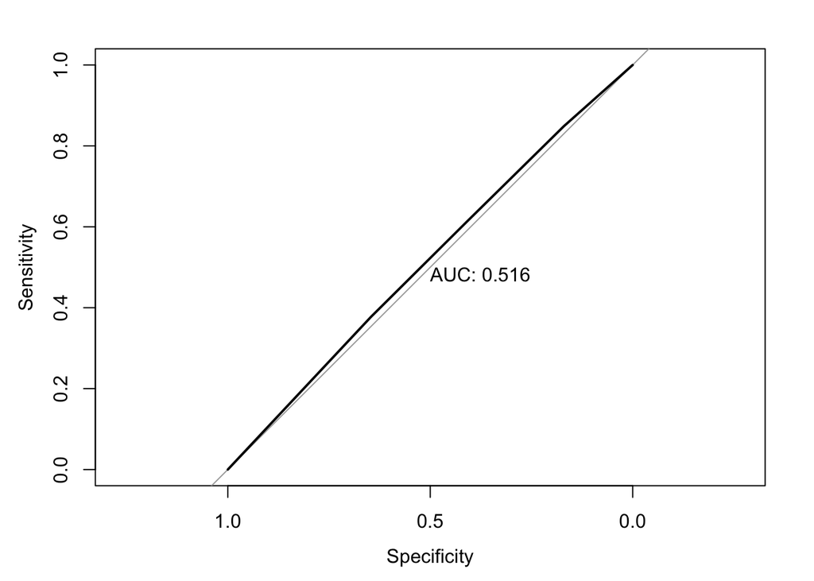

```r
plot(roc.test, print.auc = TRUE)
```

```r
#Set base level to "Day"

df$CRASH_TIME_OF_DAY <- relevel(as.factor(df$CRASH_TIME_OF_DAY),"Day")

model_TOD <- glm(IOD ~ CRASH_TIME_OF_DAY ,family=binomial(link='logit'),data=df)

summary(model_TOD)
```

```
##
## Call:
## glm(formula = IOD ~ CRASH_TIME_OF_DAY, family = binomial(link = "logit"),
##     data = df)
##
## Coefficients:
##                         Estimate Std. Error  z value Pr(>|z|)
## (Intercept)            -1.580471   0.004816 -328.148  < 2e-16 ***
## CRASH_TIME_OF_DAYDawn   0.145983   0.022527    6.480 9.15e-11 ***
## CRASH_TIME_OF_DAYDusk   0.078972   0.017428    4.531 5.86e-06 ***
## CRASH_TIME_OF_DAYNight  0.308577   0.008653   35.662  < 2e-16 ***
## ---
## Signif. codes:  0 '***' 0.001 '**' 0.01 '*' 0.05 '.' 0.1 ' ' 1
##
## (Dispersion parameter for binomial family taken to be 1)
##
##     Null deviance: 434252  on 454863  degrees of freedom
## Residual deviance: 433003  on 454860  degrees of freedom
## AIC: 433011
##
## Number of Fisher Scoring iterations: 4
```

```r
df$IOD.Pred <- predict(model_TOD,newdata=df,type='response')

roc.test <- roc(df$IOD, df$IOD.Pred )
```

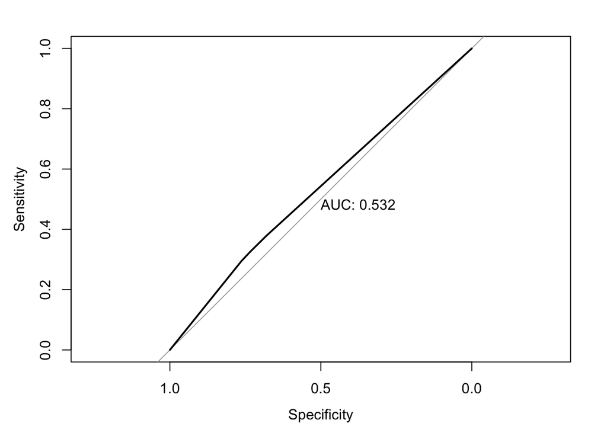

```r
plot(roc.test, print.auc = TRUE)
```

```r
model_uv <- glm(IOD ~ uvindex ,family=binomial(link='logit'),data=df)

summary(model_uv)
```

```
##
## Call:
## glm(formula = IOD ~ uvindex, family = binomial(link = "logit"),
##     data = df)
##
## Coefficients:
##              Estimate Std. Error z value Pr(>|z|)
## (Intercept) -1.293989   0.006089 -212.51   <2e-16 ***
## uvindex     -0.034596   0.001903  -18.18   <2e-16 ***
## ---
## Signif. codes:  0 '***' 0.001 '**' 0.01 '*' 0.05 '.' 0.1 ' ' 1
##
## (Dispersion parameter for binomial family taken to be 1)
##
##     Null deviance: 275985  on 273243  degrees of freedom
## Residual deviance: 275647  on 273242  degrees of freedom
##   (181620 observations deleted due to missingness)
## AIC: 275651
##
## Number of Fisher Scoring iterations: 4
```

```r
df$IOD.Pred <- predict(model_uv,newdata=df,type='response')

roc.test <- roc(df$IOD, df$IOD.Pred )
```

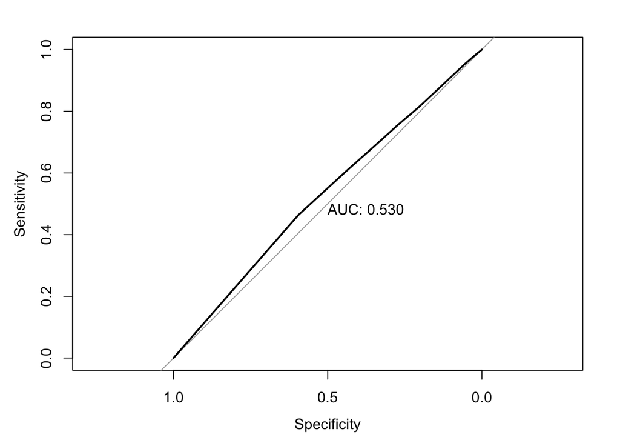

```r
plot(roc.test, print.auc = TRUE)
```

Unfortunately, we cannot include UV index because it contains too many N/A values. Also, it would be heavily aliased with the time-of-day variable.

```r
df$DENSITY <- df$POPULATION / df$AREA

model_density <- glm(IOD ~ DENSITY ,family=binomial(link='logit'),data=df)
summary(model_density)
```

```
##
## Call:
## glm(formula = IOD ~ DENSITY, family = binomial(link = "logit"),
##     data = df)
##
## Coefficients:
##               Estimate Std. Error z value Pr(>|z|)
## (Intercept) -1.231e+00  7.022e-03 -175.33   <2e-16 ***
## DENSITY     -1.745e+02  4.122e+00  -42.34   <2e-16 ***
## ---
## Signif. codes:  0 '***' 0.001 '**' 0.01 '*' 0.05 '.' 0.1 ' ' 1
##
## (Dispersion parameter for binomial family taken to be 1)
##
##     Null deviance: 434252  on 454863  degrees of freedom
## Residual deviance: 432311  on 454862  degrees of freedom
## AIC: 432315
##
## Number of Fisher Scoring iterations: 4
```

```r
df$IOD.Pred <- predict(model_density,newdata=df,type='response')

roc.test <- roc(df$IOD, df$IOD.Pred )
```

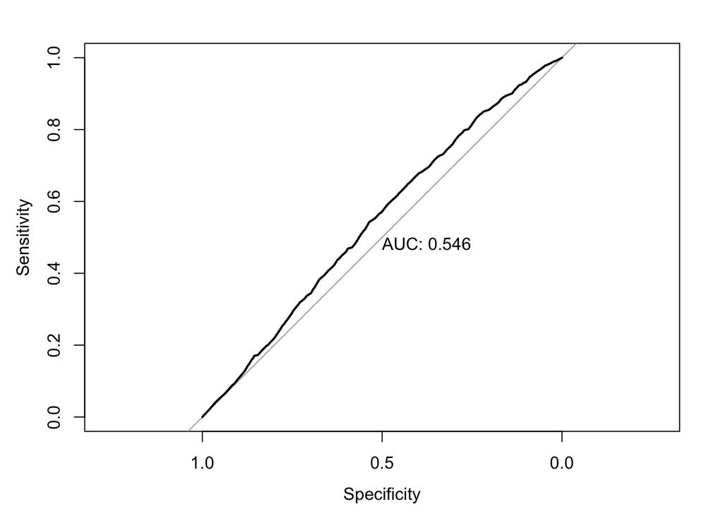

```r
plot(roc.test, print.auc = TRUE)
```

Zip code population density is a statistically-significant variable. It is much easier to drive faster in less dense areas, and you’ll probably see larger sections of highway. In reality, this variable is probably just a proxy for whether or not the accident occured in Staten Island.

```r
#Set base level to "Winter"

df$CRASH_SEASON <- relevel(as.factor(df$CRASH_SEASON),"Winter")


model_season <- glm(IOD ~ CRASH_SEASON ,family=binomial(link='logit'),data=df)

summary(model_season)
```

```
##
## Call:
## glm(formula = IOD ~ CRASH_SEASON, family = binomial(link = "logit"),
##     data = df)
##
## Coefficients:
##                     Estimate Std. Error  z value Pr(>|z|)
## (Intercept)        -1.607934   0.008393 -191.583  < 2e-16 ***
## CRASH_SEASONFall    0.156741   0.011132   14.081  < 2e-16 ***
## CRASH_SEASONSpring  0.076965   0.011507    6.688 2.26e-11 ***
## CRASH_SEASONSummer  0.209573   0.011070   18.931  < 2e-16 ***
## ---
## Signif. codes:  0 '***' 0.001 '**' 0.01 '*' 0.05 '.' 0.1 ' ' 1
##
## (Dispersion parameter for binomial family taken to be 1)
##
##     Null deviance: 434252  on 454863  degrees of freedom
## Residual deviance: 433836  on 454860  degrees of freedom
## AIC: 433844
##
## Number of Fisher Scoring iterations: 4
```

```r
df$IOD.Pred <- predict(model_season,newdata=df,type='response')

roc.test <- roc(df$IOD, df$IOD.Pred )
```

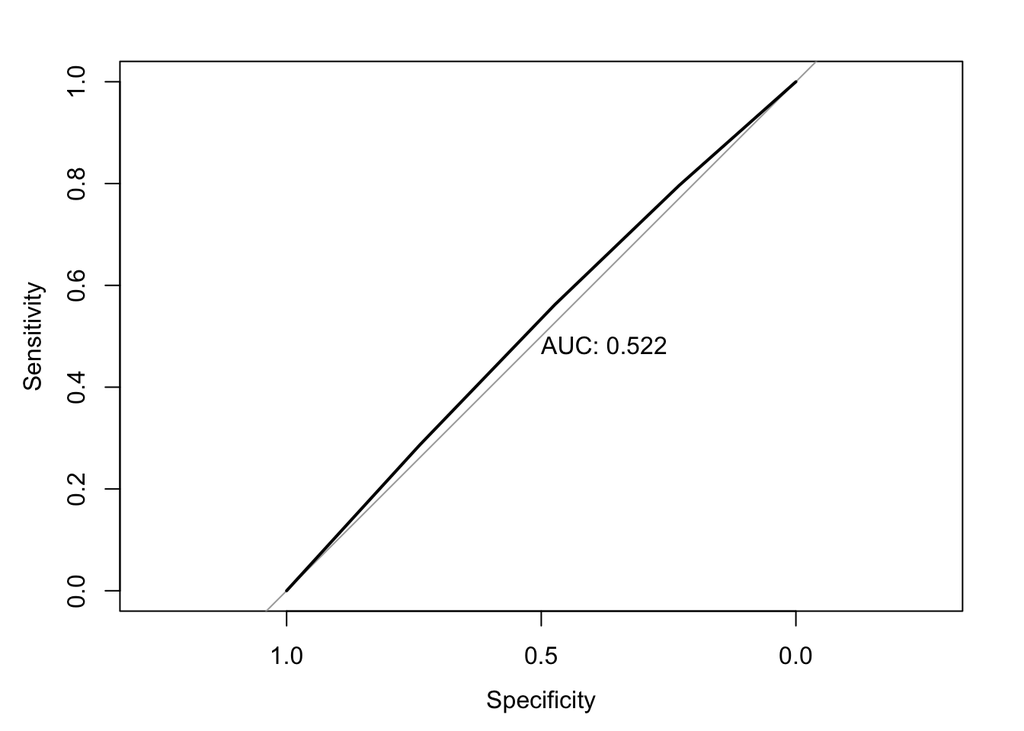

```r
plot(roc.test, print.auc = TRUE)
```

Risk for severe collisions is highest in the summer. Why? Who knows? Faster driving, more drinking, and more motorcycles and bicycles. (As Majed pointed out, not many New Yorkers ride bicycles in the winter.)

```r
df$VEHICLE_WEIGHT_DIFFERENTIAL <- abs(df$VEHICLE_WEIGHT_1 - df$VEHICLE_WEIGHT_2)

model_weight <- glm(IOD ~ log(VEHICLE_WEIGHT_1) + log(VEHICLE_WEIGHT_2) + VEHICLE_WEIGHT_DIFFERENTIAL ,family=binomial(link='logit'),data=df)

summary(model_weight)
```

```
##
## Call:
## glm(formula = IOD ~ log(VEHICLE_WEIGHT_1) + log(VEHICLE_WEIGHT_2) +
##     VEHICLE_WEIGHT_DIFFERENTIAL, family = binomial(link = "logit"),
##     data = df)
##
## Coefficients:
##                               Estimate Std. Error z value Pr(>|z|)
## (Intercept)                  1.007e+01  1.732e-01   58.13   <2e-16 ***
## log(VEHICLE_WEIGHT_1)       -6.942e-01  1.202e-02  -57.77   <2e-16 ***
## log(VEHICLE_WEIGHT_2)       -7.012e-01  1.191e-02  -58.85   <2e-16 ***
## VEHICLE_WEIGHT_DIFFERENTIAL  3.283e-05  8.092e-07   40.57   <2e-16 ***
## ---
## Signif. codes:  0 '***' 0.001 '**' 0.01 '*' 0.05 '.' 0.1 ' ' 1
##
## (Dispersion parameter for binomial family taken to be 1)
##
##     Null deviance: 434252  on 454863  degrees of freedom
## Residual deviance: 428339  on 454860  degrees of freedom
## AIC: 428347
##
## Number of Fisher Scoring iterations: 4
```

```r
df$IOD.Pred <- predict(model_weight,newdata=df,type='response')

roc.test <- roc(df$IOD, df$IOD.Pred )
```

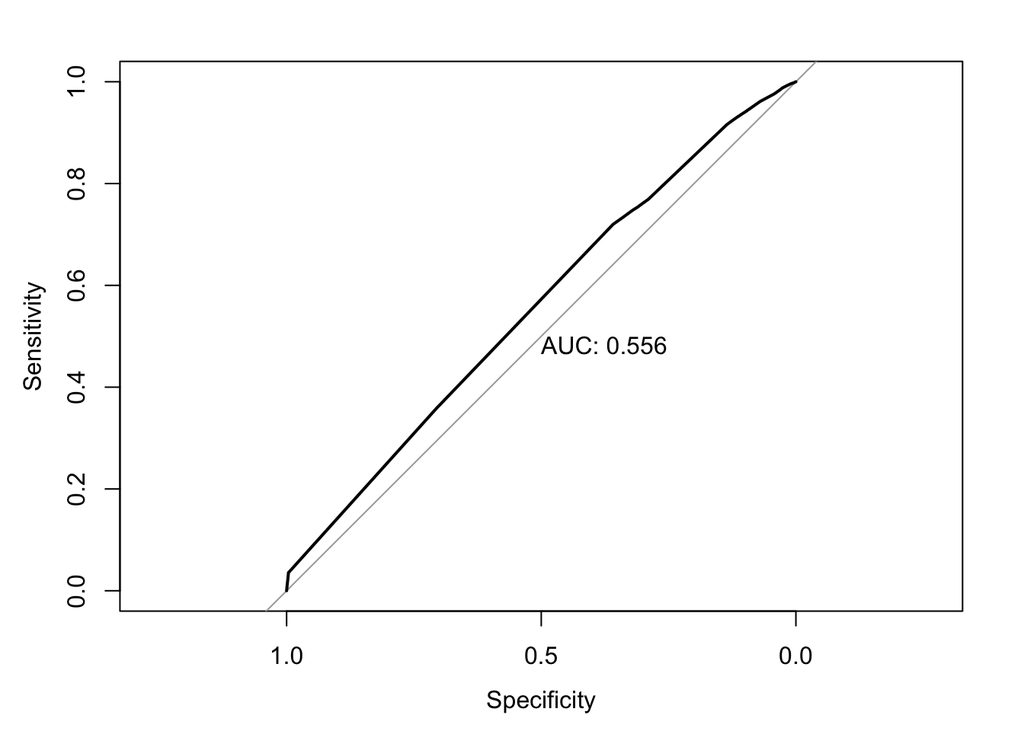

```r
plot(roc.test, print.auc = TRUE)
```

Vehicle Weight was calculated through the extremely scientific process of asking Google how much a particular type of vehicle weighs. There is a clear relationship between the weight of a vehicle and the risk of injury in an accident, and the relationship becomes stronger when you take the log of the weight. I was hoping to find a strong relationship between the weight differential between two vehicles but the coefficient is small, so I left it out of the final model. More detailed work will need to be done to determine the impact of weight differential on collision severity.

```r
model_weath <- glm(IOD ~ feelslike + precipprob + windspeed,family=binomial(link='logit'),data=df)

summary(model_weath)
```

```
##
## Call:
## glm(formula = IOD ~ feelslike + precipprob + windspeed, family = binomial(link = "logit"),
##     data = df)
##
## Coefficients:
##               Estimate Std. Error  z value Pr(>|z|)
## (Intercept) -1.7762553  0.0150420 -118.086  < 2e-16 ***
## feelslike    0.0037019  0.0001869   19.805  < 2e-16 ***
## precipprob  -0.0004703  0.0001144   -4.111 3.94e-05 ***
## windspeed    0.0086502  0.0007906   10.941  < 2e-16 ***
## ---
## Signif. codes:  0 '***' 0.001 '**' 0.01 '*' 0.05 '.' 0.1 ' ' 1
##
## (Dispersion parameter for binomial family taken to be 1)
##
##     Null deviance: 434252  on 454863  degrees of freedom
## Residual deviance: 433786  on 454860  degrees of freedom
## AIC: 433794
##
## Number of Fisher Scoring iterations: 4
```

```r
df$IOD.Pred <- predict(model_weath,newdata=df,type='response')

roc.test <- roc(df$IOD, df$IOD.Pred )
```

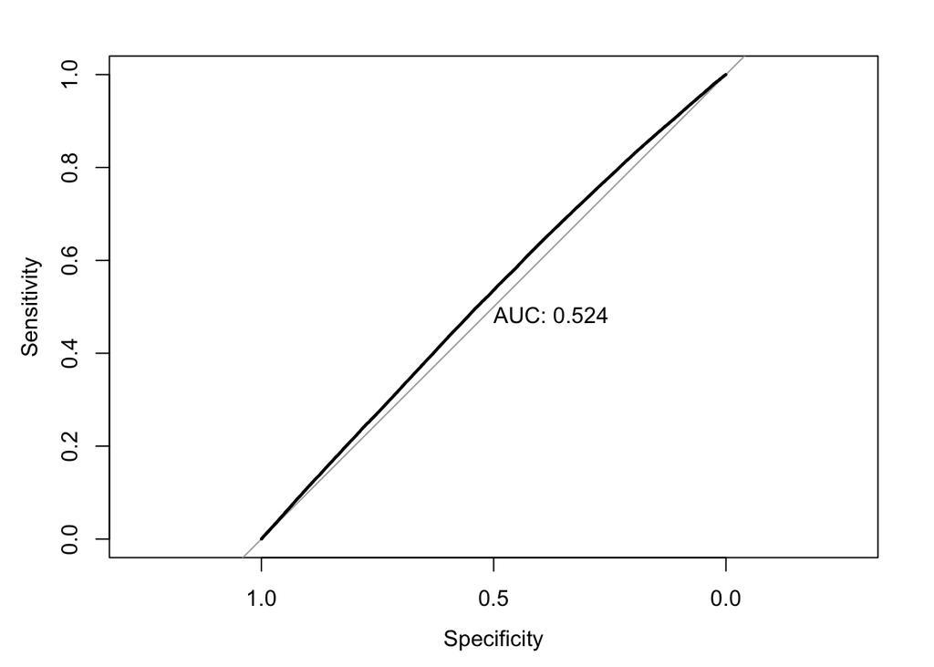

```r
plot(roc.test, print.auc = TRUE)
```

Precipitation: This is a weird one - accidents that occur while it’s raining are actually less likely to be severe than when the weather is nice. At first I was thinking that people might drive more carefully in the rain, but then I came to my senses and realized that it’s probably because there aren’t as many people on motorcycles and bicycles. Perceived temperature probably has the opposite effect. The relationship between windspeed seems self-evident.

```r
model_fin <- glm(IOD ~ DRIVER_SEX_1 + DRIVER_SEX_2 + poly(DRIVER_AGE_1,2) + poly(DRIVER_AGE_2,2) + licensed_1 + licensed_2 + instate_lic_1 + instate_lic_2 + safe_1 + safe_2 + DENSITY + feelslike + precipprob + windspeed + CRASH_TIME_OF_DAY + log(VEHICLE_WEIGHT_1) + log(VEHICLE_WEIGHT_2) + CRASH_SEASON,family=binomial(link='logit'),data=df)
summary(model_fin)
```

```
##
## Call:
## glm(formula = IOD ~ DRIVER_SEX_1 + DRIVER_SEX_2 + poly(DRIVER_AGE_1,
##     2) + poly(DRIVER_AGE_2, 2) + licensed_1 + licensed_2 + instate_lic_1 +
##     instate_lic_2 + safe_1 + safe_2 + DENSITY + feelslike + precipprob +
##     windspeed + CRASH_TIME_OF_DAY + log(VEHICLE_WEIGHT_1) + log(VEHICLE_WEIGHT_2) +
##     CRASH_SEASON, family = binomial(link = "logit"), data = df)
##
## Coefficients:
##                          Estimate Std. Error z value Pr(>|z|)
## (Intercept)             4.897e+00  1.161e-01  42.180  < 2e-16 ***
## DRIVER_SEX_1M          -6.700e-02  8.670e-03  -7.727 1.10e-14 ***
## DRIVER_SEX_2M          -6.339e-02  8.717e-03  -7.271 3.56e-13 ***
## poly(DRIVER_AGE_1, 2)1 -4.803e+01  2.643e+00 -18.172  < 2e-16 ***
## poly(DRIVER_AGE_1, 2)2  1.010e+01  2.626e+00   3.847 0.000119 ***
## poly(DRIVER_AGE_2, 2)1 -5.038e+01  2.642e+00 -19.068  < 2e-16 ***
## poly(DRIVER_AGE_2, 2)2  1.122e+01  2.625e+00   4.273 1.93e-05 ***
## licensed_1             -6.681e-01  2.877e-02 -23.219  < 2e-16 ***
## licensed_2             -5.453e-01  2.806e-02 -19.432  < 2e-16 ***
## instate_lic_1           1.625e-01  1.219e-02  13.337  < 2e-16 ***
## instate_lic_2           1.706e-01  1.206e-02  14.138  < 2e-16 ***
## safe_1                 -1.023e-01  8.024e-03 -12.753  < 2e-16 ***
## safe_2                 -1.128e-01  8.023e-03 -14.057  < 2e-16 ***
## DENSITY                -1.540e+02  4.282e+00 -35.970  < 2e-16 ***
## feelslike               3.140e-03  3.015e-04  10.414  < 2e-16 ***
## precipprob             -3.965e-04  1.156e-04  -3.429 0.000607 ***
## windspeed               5.400e-03  8.273e-04   6.527 6.72e-11 ***
## CRASH_TIME_OF_DAYDawn   2.526e-01  2.323e-02  10.874  < 2e-16 ***
## CRASH_TIME_OF_DAYDusk   6.049e-02  1.770e-02   3.418 0.000631 ***
## CRASH_TIME_OF_DAYNight  3.171e-01  9.306e-03  34.069  < 2e-16 ***
## log(VEHICLE_WEIGHT_1)  -3.219e-01  8.983e-03 -35.830  < 2e-16 ***
## log(VEHICLE_WEIGHT_2)  -3.337e-01  8.839e-03 -37.749  < 2e-16 ***
## CRASH_SEASONFall        9.227e-02  1.379e-02   6.689 2.25e-11 ***
## CRASH_SEASONSpring      6.881e-02  1.304e-02   5.277 1.31e-07 ***
## CRASH_SEASONSummer      1.238e-01  1.747e-02   7.088 1.36e-12 ***
## ---
## Signif. codes:  0 '***' 0.001 '**' 0.01 '*' 0.05 '.' 0.1 ' ' 1
##
## (Dispersion parameter for binomial family taken to be 1)
##
##     Null deviance: 434252  on 454863  degrees of freedom
## Residual deviance: 423549  on 454839  degrees of freedom
## AIC: 423599
##
## Number of Fisher Scoring iterations: 4
```

```r
df$IOD.Pred <- predict(model_fin,newdata=df,type='response')

roc.test <- roc(df$IOD, df$IOD.Pred )
```

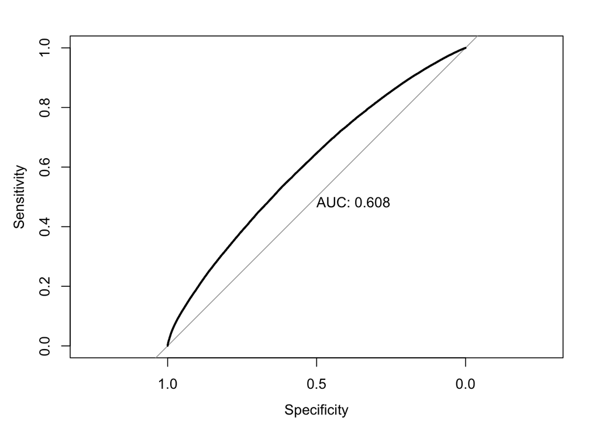

```r
plot(roc.test, print.auc = TRUE)
```

```r
vif(model_fin)
```

```
##                           GVIF Df GVIF^(1/(2*Df))
## DRIVER_SEX_1          1.023338  1        1.011601
## DRIVER_SEX_2          1.023072  1        1.011470
## poly(DRIVER_AGE_1, 2) 1.032765  2        1.008092
## poly(DRIVER_AGE_2, 2) 1.034466  2        1.008507
## licensed_1            1.006345  1        1.003168
## licensed_2            1.006185  1        1.003088
## instate_lic_1         1.014233  1        1.007091
## instate_lic_2         1.014988  1        1.007466
## safe_1                1.023954  1        1.011906
## safe_2                1.024403  1        1.012128
## DENSITY               1.063547  1        1.031284
## feelslike             2.691649  1        1.640625
## precipprob            1.008743  1        1.004362
## windspeed             1.128933  1        1.062512
## CRASH_TIME_OF_DAY     1.166686  3        1.026028
## log(VEHICLE_WEIGHT_1) 1.033837  1        1.016778
## log(VEHICLE_WEIGHT_2) 1.034121  1        1.016917
## CRASH_SEASON          2.538734  3        1.167982
```

Interesting variables that weren’t useful:

Car age: I would have thought that older cars would be more likely to be involved in severe accidents due to the lack of new technologies such as airbags. But it wasn’t the case.

Weight differential: See description above. As a general rule, accidents with heavier vehicles are less likely to involve injuries.

Visibility: No relationship